# L06 Scales, Axes, & Legends

Data Visualization (STAT 302)

Author

Bud Green

## Overview

The goal of this lab is to explore ways to manage and manipulate scales, axes, and legends within `ggplot2`.

## Datasets

We’ll be using the `tech_stocks.rda`, `corruption.rda`, `cdc.txt`, and a toy dataset.

```r
# load package(s)
library(tidyverse)
library(scales)
library(ggrepel)

# load datasets
load("data/tech_stocks.rda")
load("data/corruption.rda")

# Read in the cdc dataset
cdc <- read_delim(file = "data/cdc.txt", delim = "|") |>
  mutate(
    genhlth = factor(
      genhlth,
      levels = c("excellent", "very good", "good", "fair", "poor")
      )
    )

# set seed
set.seed(86420)

# selecting a random subset of size 100
cdc_small <- cdc |> slice_sample(n = 100)

# Generating toy dataset for exercise 2
toy_data <- tibble(
  theta = seq(0, 2 * pi, length.out = 100),
  obs = rnorm(100, sin(theta), 0.1),
  larger_than = if_else(abs(obs) > abs(sin(theta)), "1", "0")
)
```

## Exercise 1

Using the `tech_stocks` dataset, recreate the following graphic as precisely as possible.

*Hints:*

- `key_glyph`
- `scales` package will be useful
- legend `linewidth` is 1.3
- legend useful values: 0.75 and 0.85
- Eliminated extra space in horizontal direction

**Solution**

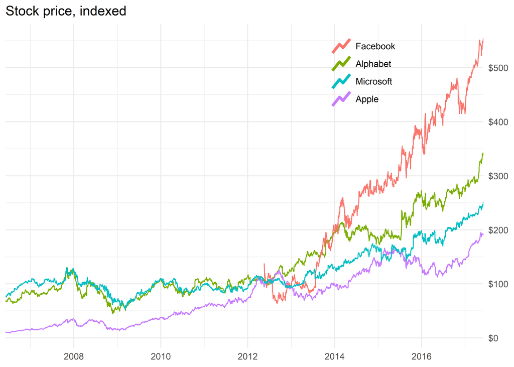

```r
x_range <- (range(tech_stocks$date))
y_range <- (range(tech_stocks$price_indexed))

ggplot(
  data = tech_stocks, aes(date, price_indexed)
  ) +
  geom_line(
    mapping = aes(color = company),
    key_glyph = "timeseries"
    ) +
  scale_color_discrete(
    name = NULL,
    limits = c("Facebook", "Alphabet", "Microsoft", "Apple"),
  ) +
  scale_y_continuous(
    name = NULL,
    position = "right",
    breaks = seq(0, 500, 100),
    labels = scales::label_currency(prefix = "$")
  ) +
  scale_x_date(
    name = NULL,
    expand = c(0, 0)
  ) +
  theme_minimal() +
  theme(
    legend.position = "inside",
    legend.position.inside = c(0.75, 0.85),
    ) +
  guides(
    color = guide_legend(override.aes = list(linewidth = 1.3))
    ) +
  labs(
    title = "Stock price, indexed",
  )
```

## Exercise 2

Using the `corruption.rda` dataset, recreate the following graphic as precisely as possible.

*Hints:*

- Only use 2015 data
- Transparency is 0.6
- `"y ~ log(x)"`; method `"lm"`; and color is `grey40`
- Point size is 3 in legend
- color palette is `"Set1"`
- Package `ggrepel`
  - `box.padding` is 0.6
  - Minimum segment length is 0
  - seed is 9876

**Solution**

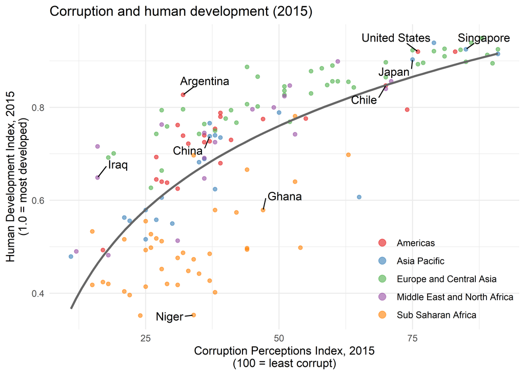

```r
#not sure why the paddings and placements for the country names are off from the instructions, but when I render it it looks the same as the instructions.

region_colors <- RColorBrewer::brewer.pal(length(unique(corruption$region)), "Set1")
ggplot(
  data = subset(corruption, year == 2015 & !is.na(cpi) & !is.na(hdi)),
  aes(cpi, hdi, color = region)
  ) +
  geom_point(alpha = 0.6) +
  geom_smooth(
    method = "lm",
    formula = "y ~ log(x)",
    color = "grey40",
    se = FALSE
    ) +
  scale_color_manual(values = region_colors) +
  theme_minimal() +
  labs(
    title = "Corruption and human development (2015)",
    x = "Corruption Perceptions Index, 2015\n(100 = least corrupt)",
    y = "Human Development Index, 2015\n(1.0 = most developed)"
    ) +
  geom_text_repel(
    data = subset(corruption, year == 2015 &!is.na(cpi) & !is.na(hdi) & country %in% c("United States", "Singapore", "Japan", "Chile", "Niger", "Ghana", "Argentina", "China", "Iraq")),
    aes(label = country),
    seed = 9876,
    box.padding = 0.6,
    min.segment.length = 0,
    color = "black"
    ) +
  theme(
    legend.position = "inside",
    legend.justification = c(1,0),
    legend.title = element_blank(),
  ) +
  guides(color = guide_legend(override.aes = list(size = 3)))
```

## Exercise 3

Use `toy_data` to recreate the following graphic as precisely as possible.

*Hints:*

- Point sizes are 3
- Point colors: `#E66100`, `#5D3A9B`
- Point transparency is 0.8
- `stat_function()` will be useful
  - line size is 1.3 and line color is `#56B4E9`
- `quote()` will be useful

**Solution**

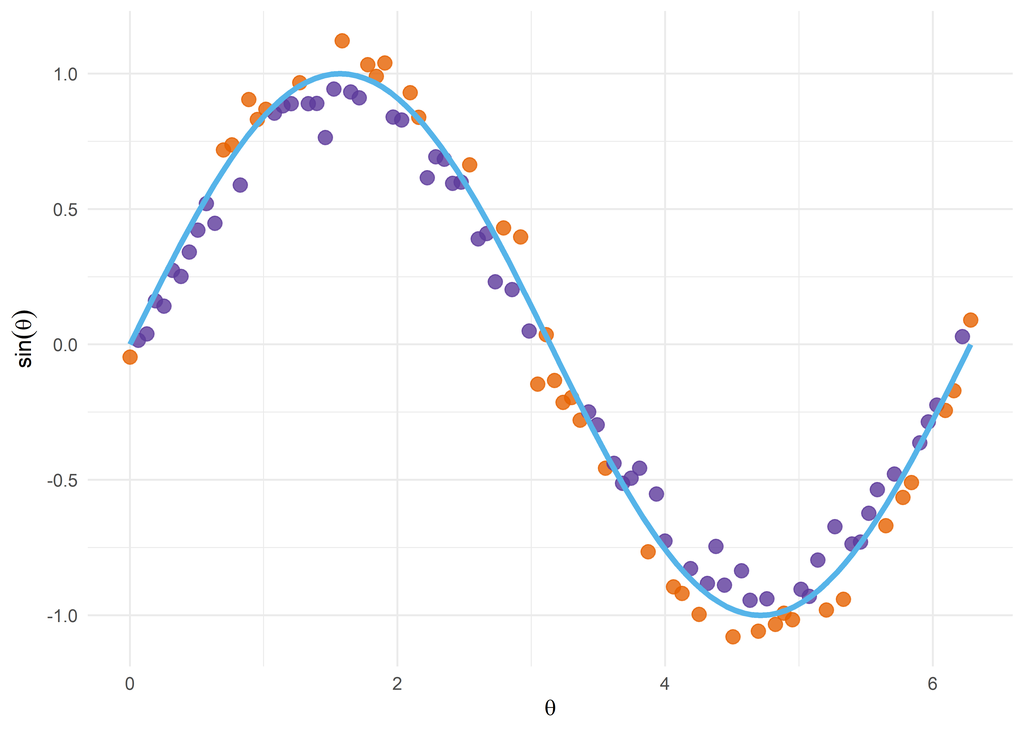

```r
ggplot(toy_data, aes(theta, obs)) +
  geom_point(aes(color = larger_than), size = 3, alpha = 0.8) +
  stat_function(fun = function(x) sin(x), aes(color = "sin(theta)"), size = 1.3) +
  scale_color_manual(
    values = c("#5d3a9b", "#e66100", "#56b4e9"),
    labels = c("obs <= sin(theta)", "obs > sin(theta)", "sin(theta)")
    ) +
  labs(
       x = expression(theta),
       y = expression(sin(theta))
       ) +
  theme_minimal() +
  theme(legend.position = "none")
```

## Exercise 4

Using `cdc_small`, construct a scatterplot of `weight` by `height` with the following requirements:

- Size of plotting characters should be 3.
- Color and shape should both identify `genhlth`.
- Only one legend: for both color and shape.
- Legend title should be “General Health?” with a newline starting after general.
- Legend categories should be ordered from excellent (top) to poor (bottom) with each word in category capitalized in the legend.
- Legend should be placed in the lower right-hand corner of the plotting area.
- Color should follow the `"Set1"` palette.
- Shape should have a solid triangle (17) for excellent, solid circle (19) for very good, an `x` (4) for poor, an hollow rotated square with an `x` in it (9) for fair, and a solid square (15) for good.
- `height` values should be limited between 55 and 80.
- `height` axis should display every 5th number between 55 and 80 and be appropriately labeled (i.e. `55 in`, `60 in`, …, `80 in`). No axis title is necessary.
- `weight` values should be limited between 100 and 300.
- `weight` axis should be `trans` to log base 10 scale, but still display weights in pounds starting at 100 and displaying every 25 pounds until 300. Must be appropriately labeled (i.e. `100 lbs`, `125 lbs`, …, `300 lbs`). No axis title is necessary.
- Graph title should be `CDC BRFSS: Weight by Height`.
- Minimal theme.

**Solution**

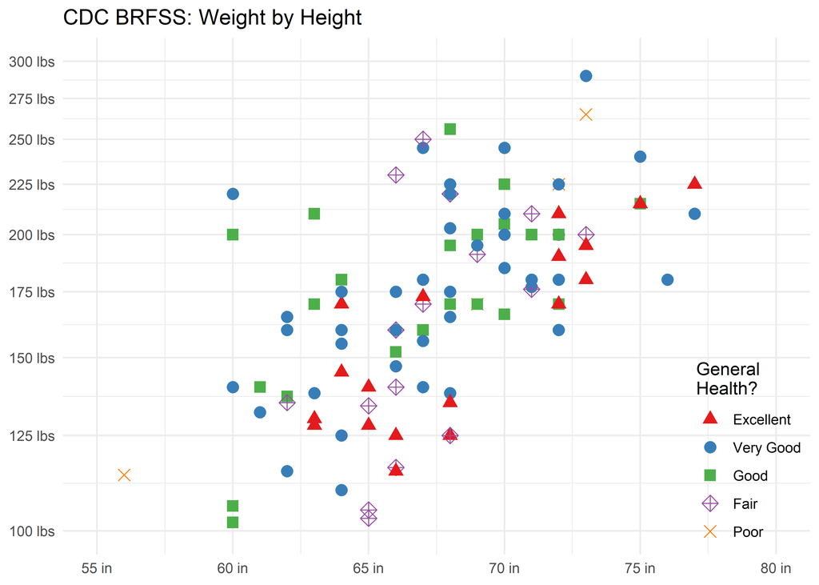

```r
shape_map <- c("excellent" = 17, "very good" = 19, "good" = 15, "fair" = 9, "poor" = 4)
color_map <- RColorBrewer::brewer.pal(length(unique(cdc_small$genhlth)), "Set1")
legend_labels <- c("Excellent", "Very Good", "Good", "Fair", "Poor")


# Create the plot
ggplot(cdc_small, aes(height, weight, color = genhlth, shape = genhlth)) +
  geom_point(size = 3) +
  scale_shape_manual(values = shape_map, labels = legend_labels) +
  scale_color_manual(values = color_map, labels = legend_labels) +
  scale_y_continuous(
    limits = c(100, 300),
    breaks = seq(100, 300, by = 25),
    trans = "log10",
    labels = function(x) paste0(x, " lbs")
  ) +
  scale_x_continuous(
    limits = c(55, 80),
    breaks = seq(55, 80, by = 5),
    labels = function(x) paste0(x, " in")
  ) +
  labs(title = "CDC BRFSS: Weight by Height") +
  theme_minimal() +
  guides(
    shape = guide_legend(
      title = "General\nHealth?",
      override.aes = list(color = color_map),
      order = 1),
    color = "none"
    ) +
  theme(
    legend.position = "inside",
    legend.justification = c(1, 0),
    axis.title.y = element_blank(),
    axis.title.x = element_blank()
    )
```